# Ch 13: Relational Data

## Prerequisites

```r
library(tidyverse)
library(nycflights13)
```

ideas

- keys: primary key, foreign key,
- mutating joins: `left_join`, `right_join`, `inner_join`, `full_join`
- `merge` vs. joins
- filtering joins: `semi_join`, `anti_join`
- set operations: `intersect`, `union`, `setdiff`

**TODO**: fuzzy joining

## nycflights13

**NOTES**

[nycflights13](https://cran.r-project.org/web/packages/nycflights13/index.html) is an example of a **data-only** R package. R packages can contain both functions and data. Since data-sets can get large, often they can be packaged as their own dataset. These sorts of data-only R packages make it convenient for R users to access your data, but it should not be the only way you provide your research data. Not everyone uses R, so the original data should be provided in a program agnostic format (e.g. csv files). This also holds for those using Stata; they should not be distributing data in `.dta` format files specific to Stata (even if as we saw earlier, other programs can read that data.) Another example of a data-only R package is gapminder.

How does Hadley create his diagrams?

The four tables in the **nycflights13** package:

| carrier | name |
| --- | --- |
| 9E | Endeavor Air Inc. |
| AA | American Airlines Inc. |
| AS | Alaska Airlines Inc. |
| B6 | JetBlue Airways |
| DL | Delta Air Lines Inc. |
| EV | ExpressJet Airlines Inc. |
| F9 | Frontier Airlines Inc. |
| FL | AirTran Airways Corporation |
| HA | Hawaiian Airlines Inc. |
| MQ | Envoy Air |

[output cut: 6 more lines]

| faa | name | lat | lon | alt | tz | dst |
| --- | --- | --- | --- | --- | --- | --- |
| 04G | Lansdowne Airport | 41.13047 | -80.61958 | 1044 | -5 | A |
| 06A | Moton Field Municipal Airport | 32.46057 | -85.68003 | 264 | -5 | A |
| 06C | Schaumburg Regional | 41.98934 | -88.10124 | 801 | -6 | A |
| 06N | Randall Airport | 41.43191 | -74.39156 | 523 | -5 | A |
| 09J | Jekyll Island Airport | 31.07447 | -81.42778 | 11 | -4 | A |
| 0A9 | Elizabethton Municipal Airport | 36.37122 | -82.17342 | 1593 | -4 | A |
| 0G6 | Williams County Airport | 41.46731 | -84.50678 | 730 | -5 | A |
| 0G7 | Finger Lakes Regional Airport | 42.88356 | -76.78123 | 492 | -5 | A |
| 0P2 | Shoestring Aviation Airfield | 39.79482 | -76.64719 | 1000 | -5 | U |
| 0S9 | Jefferson County Intl | 48.05381 | -122.81064 | 108 | -8 | A |

[output cut: 990 more lines]

| tailnum | year | type | manufacturer | model | engines | seats | speed | engine |
| --- | --- | --- | --- | --- | --- | --- | --- | --- |
| N10156 | 2004 | Fixed wing multi engine | EMBRAER | EMB-145XR | 2 | 55 | NA | Turbo-fan |
| N102UW | 1998 | Fixed wing multi engine | AIRBUS INDUSTRIE | A320-214 | 2 | 182 | NA | Turbo-fan |
| N103US | 1999 | Fixed wing multi engine | AIRBUS INDUSTRIE | A320-214 | 2 | 182 | NA | Turbo-fan |
| N104UW | 1999 | Fixed wing multi engine | AIRBUS INDUSTRIE | A320-214 | 2 | 182 | NA | Turbo-fan |
| N10575 | 2002 | Fixed wing multi engine | EMBRAER | EMB-145LR | 2 | 55 | NA | Turbo-fan |
| N105UW | 1999 | Fixed wing multi engine | AIRBUS INDUSTRIE | A320-214 | 2 | 182 | NA | Turbo-fan |
| N107US | 1999 | Fixed wing multi engine | AIRBUS INDUSTRIE | A320-214 | 2 | 182 | NA | Turbo-fan |
| N108UW | 1999 | Fixed wing multi engine | AIRBUS INDUSTRIE | A320-214 | 2 | 182 | NA | Turbo-fan |
| N109UW | 1999 | Fixed wing multi engine | AIRBUS INDUSTRIE | A320-214 | 2 | 182 | NA | Turbo-fan |
| N110UW | 1999 | Fixed wing multi engine | AIRBUS INDUSTRIE | A320-214 | 2 | 182 | NA | Turbo-fan |

[output cut: 990 more lines]

| origin | year | month | day | hour | temp | dewp | humid | wind_dir | wind_speed | wind_gust | precip | pressure | visib | time_hour |
| --- | --- | --- | --- | --- | --- | --- | --- | --- | --- | --- | --- | --- | --- | --- |
| EWR | 2013 | 1 | 1 | 0 | 37.04 | 21.92 | 53.97 | 230 | 10.35702 | 11.918651 | 0.00 | 1013.9 | 10.00 | 2012-12-31 16:00:00 |
| EWR | 2013 | 1 | 1 | 1 | 37.04 | 21.92 | 53.97 | 230 | 13.80936 | 15.891535 | 0.00 | 1013.0 | 10.00 | 2012-12-31 17:00:00 |
| EWR | 2013 | 1 | 1 | 2 | 37.94 | 21.92 | 52.09 | 230 | 12.65858 | 14.567241 | 0.00 | 1012.6 | 10.00 | 2012-12-31 18:00:00 |
| EWR | 2013 | 1 | 1 | 3 | 37.94 | 23.00 | 54.51 | 230 | 13.80936 | 15.891535 | 0.00 | 1012.7 | 10.00 | 2012-12-31 19:00:00 |
| EWR | 2013 | 1 | 1 | 4 | 37.94 | 24.08 | 57.04 | 240 | 14.96014 | 17.215830 | 0.00 | 1012.8 | 10.00 | 2012-12-31 20:00:00 |
| EWR | 2013 | 1 | 1 | 6 | 39.02 | 26.06 | 59.37 | 270 | 10.35702 | 11.918651 | 0.00 | 1012.0 | 10.00 | 2012-12-31 22:00:00 |
| EWR | 2013 | 1 | 1 | 7 | 39.02 | 26.96 | 61.63 | 250 | 8.05546 | 9.270062 | 0.00 | 1012.3 | 10.00 | 2012-12-31 23:00:00 |
| EWR | 2013 | 1 | 1 | 8 | 39.02 | 28.04 | 64.43 | 240 | 11.50780 | 13.242946 | 0.00 | 1012.5 | 10.00 | 2013-01-01 00:00:00 |
| EWR | 2013 | 1 | 1 | 9 | 39.92 | 28.04 | 62.21 | 250 | 12.65858 | 14.567241 | 0.00 | 1012.2 | 10.00 | 2013-01-01 01:00:00 |
| EWR | 2013 | 1 | 1 | 10 | 39.02 | 28.04 | 64.43 | 260 | 12.65858 | 14.567241 | 0.00 | 1011.9 | 10.00 | 2013-01-01 02:00:00 |

[output cut: 990 more lines]

### Exercises

**TODO**

## Keys

| tailnum | n |
| --- | --- |

| year | month | day | hour | origin | n |
| --- | --- | --- | --- | --- | --- |

### Exercises

1. Imagine you wanted to draw (approximately) the route each plane flies from its origin to its destination. What variables would you need? What tables would you need to combine?
- `flights` table: `origin` and `dest`
- `airports` table: longitude and latitude variables
- We would merge the `flights` with airports twice: once to get the location of the `origin` airport, and once to get the location of the `dest` airport.
2. I forgot to draw the relationship between weather and airports. What is the relationship and how should it appear in the diagram?

The variable `origin` in `weather` is matched with `faa` in `airports`.

3. weather only contains information for the origin (NYC) airports. If it contained weather records for all airports in the USA, what additional relation would it define with `flights`?

`year`, `month`, `day`, `hour`, `origin` in `weather` would be matched to `year`, `month`, `day`, `hour`, `dest` in `flight` (though it should use the arrival date-time values for `dest` if possible).

4. We know that some days of the year are “special”, and fewer people than usual fly on them. How might you represent that data as a data frame? What would be the primary keys of that table? How would it connect to the existing tables?

I would add a table of special dates. The primary key would be date. It would match to the `year`, `month`, `day` columns of `flights.

## Keys

1. Add a surrogate key to flights.

I add the column `flight_id` as a surrogate key. I sort the data prior to making the key, even though it is not strictly necessary, so the order of the rows has some meaning.

```r
flights %>%
  arrange(year, month, day, sched_dep_time, carrier, flight) %>%
  mutate(flight_id = row_number()) %>%
  glimpse()
```

```
Observations: 336,776
Variables: 20
$ year           <int> 2013, 2013, 2013, 2013, 2013, 2013, 2...
$ month          <int> 1, 1, 1, 1, 1, 1, 1, 1, 1, 1, 1, 1, 1...
$ day            <int> 1, 1, 1, 1, 1, 1, 1, 1, 1, 1, 1, 1, 1...
$ dep_time       <int> 517, 533, 542, 544, 554, 559, 558, 55...
$ sched_dep_time <int> 515, 529, 540, 545, 558, 559, 600, 60...
$ dep_delay      <dbl> 2, 4, 2, -1, -4, 0, -2, -1, -2, -2, -...
$ arr_time       <int> 830, 850, 923, 1004, 740, 702, 753, 9...
$ sched_arr_time <int> 819, 830, 850, 1022, 728, 706, 745, 9...
$ arr_delay      <dbl> 11, 20, 33, -18, 12, -4, 8, 31, -2, -...
$ carrier        <chr> "UA", "UA", "AA", "B6", "UA", "B6", "...
$ flight         <int> 1545, 1714, 1141, 725, 1696, 1806, 30...
$ tailnum        <chr> "N14228", "N24211", "N619AA", "N804JB...
$ origin         <chr> "EWR", "LGA", "JFK", "JFK", "EWR", "J...
$ dest           <chr> "IAH", "IAH", "MIA", "BQN", "ORD", "B...
$ air_time       <dbl> 227, 227, 160, 183, 150, 44, 138, 257...
$ distance       <dbl> 1400, 1416, 1089, 1576, 719, 187, 733...
$ hour           <dbl> 5, 5, 5, 5, 5, 5, 6, 6, 6, 6, 6, 6, 6...
$ minute         <dbl> 15, 29, 40, 45, 58, 59, 0, 0, 0, 0, 0...
$ time_hour      <dttm> 2013-01-01 05:00:00, 2013-01-01 05:0...
$ flight_id      <int> 1, 2, 3, 4, 5, 6, 7, 8, 9, 10, 11, 12...
```

Identify the keys in the following datasets

1. `Lahman::Batting`
2. `babynames::babynames`
3. `nasaweather::atmos`
4. `fueleconomy::vehicles`
5. `ggplot2::diamonds`

(You might need to install some packages and read some documentation.)

The primary key for `Lahman::Batting` is `playerID`, `yearID`, `stint`. It is not simply `playerID`, `yearID` because players can have different stints in different leagues within the same year.

```r
Lahman::Batting %>%
  group_by(playerID, yearID, stint) %>%
  filter(n() > 1) %>%
  nrow()
```

```
[1] 0
```

The primary key for `babynames::babynames` is `year`, `sex`, `name`. It is no simply `year`, `name` since names can appear for both sexes with different counts.

```r
babynames::babynames %>%
  group_by(year, sex, name) %>%
  filter(n() > 1) %>%
  nrow()
```

```
[1] 0
```

The primary key for `nasaweather::atmos` is the location and time of the measurement: `lat`, `long`, `year`, `month`.

```r
nasaweather::atmos %>%
  group_by(lat, long, year, month) %>%
  filter(n() > 1) %>%
  nrow()
```

```
[1] 0
```

The column `id` (unique EPA identifier) is the primary key for `fueleconomy::vehicles`:

```r
fueleconomy::vehicles %>%
  group_by(id) %>%
  filter(n() > 1) %>%
  nrow()
```

```
[1] 0
```

There is no primary key for `ggplot2::diamonds`. Using all variables in the data frame, the number of distinct rows is less than the total number of rows, meaning no combination of variables uniquely identifies the observations.

```r
ggplot2::diamonds %>%
  distinct() %>%
  nrow()
```

```
[1] 53794
```

```r
nrow(ggplot2::diamonds)
```

```
[1] 53940
```

4. Draw a diagram illustrating the connections between the Batting, Master, and Salaries tables in the Lahman package. Draw another diagram that shows the relationship between Master, Managers, AwardsManagers.
- `Batting`
- primary key: `playerID`, `yearID`, `stint`
- foreign keys:
  - `playerID` -> `Master.playerID`
- `Master`
- primary key: `playerID`
- `Salaries`
- primary key: `yearID`, `teamID`, `playerID`
- foreign keys:
  - `playerID` -> `Master.playerID`
- `Managers`:
- primary key: `yearID`, `playerID`, `teamID`, `inseason`
- foreign keys:
  - `playerID` -> `Master.teamID`
- `Managers`:
- primary key: `awardID`, `yearID`
- `AwardsManagers`:
- primary key: `playerID`, `awardID`, `yearID` (since there are ties and while `tie` distinguishes those awards it has `NA` values)
- foreign keys:
  - `playerID` -> `Master.playerID`
  - `playerID`, `yearID`, `lgID` -> `Managers.playerID`, `yearID`, `lgID`

`lgID` and `teamID` appear in multiple tables, but should be primary keys for league and team tables.

3. How would you characterise the relationship between the Batting, Pitching, and Fielding tables?

## Mutating Joins

```r
flights2 <- flights %>%
  select(year:day, hour, origin, dest, tailnum, carrier)
flights2 %>%
  select(-origin, -dest) %>%
  left_join(airlines, by = "carrier")
```

| year | month | day | hour | tailnum | carrier | name |
| --- | --- | --- | --- | --- | --- | --- |
| 2013 | 1 | 1 | 5 | N14228 | UA | United Air Lines Inc. |
| 2013 | 1 | 1 | 5 | N24211 | UA | United Air Lines Inc. |
| 2013 | 1 | 1 | 5 | N619AA | AA | American Airlines Inc. |
| 2013 | 1 | 1 | 5 | N804JB | B6 | JetBlue Airways |
| 2013 | 1 | 1 | 6 | N668DN | DL | Delta Air Lines Inc. |
| 2013 | 1 | 1 | 5 | N39463 | UA | United Air Lines Inc. |
| 2013 | 1 | 1 | 6 | N516JB | B6 | JetBlue Airways |
| 2013 | 1 | 1 | 6 | N829AS | EV | ExpressJet Airlines Inc. |
| 2013 | 1 | 1 | 6 | N593JB | B6 | JetBlue Airways |
| 2013 | 1 | 1 | 6 | N3ALAA | AA | American Airlines Inc. |

[output cut: 990 more lines]

```r
NA
```

### Exercises

1. Compute the average delay by destination, then join on the `airports` data frame so you can show the spatial distribution of delays. Here’s an easy way to draw a map of the United States:

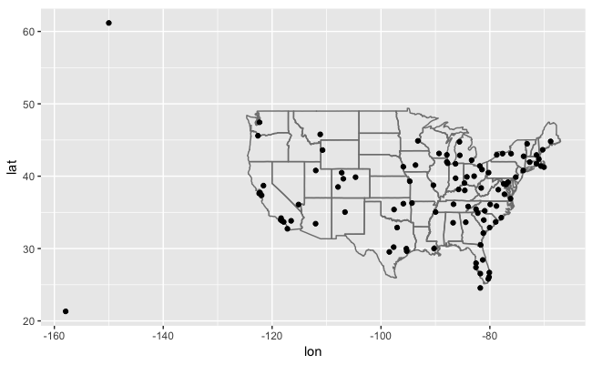

```r
airports %>%
  semi_join(flights, c("faa" = "dest")) %>%
  ggplot(aes(lon, lat)) +
    borders("state") +
    geom_point() +
    coord_quickmap()
```

(Don’t worry if you don’t understand what `semi_join()` does — you’ll learn about it next.)

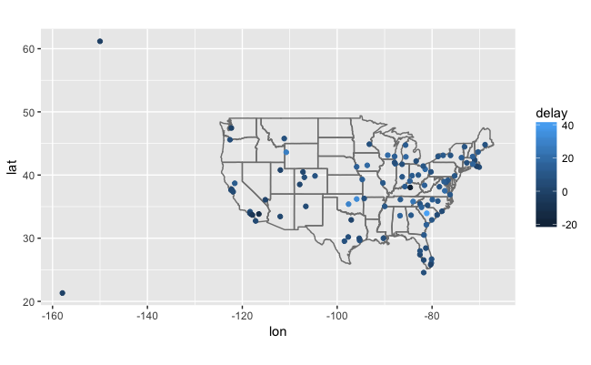

```r
avg_dest_delays <-
  flights %>%
  group_by(dest) %>%
  # arrival delay NA's are cancelled flights
  summarise(delay = mean(arr_delay, na.rm = TRUE)) %>%
  inner_join(airports, by = c(dest = "faa"))
avg_dest_delays %>%
  ggplot(aes(lon, lat, colour = delay)) +
    borders("state") +
    geom_point() +
    coord_quickmap()
```

You might want to use the size or colour of the points to display the average delay for each airport.

2. Add the location of the origin and destination (i.e. the lat and lon) to flights.

```r
flights %>%
  left_join(airports, by = c(dest = "faa")) %>%
  left_join(airports, by = c(origin = "faa")) %>%
  head()
```

| year | month | day | dep_time | sched_dep_time | dep_delay | arr_time | sched_arr_time | arr_delay | carrier | flight | tailnum | origin | dest | air_time | distance | hour | minute | time_hour | name.x | lat.x | lon.x | alt.x | tz.x | dst.x | name.y | lat.y | lon.y | alt.y | tz.y | … |
| --- | --- | --- | --- | --- | --- | --- | --- | --- | --- | --- | --- | --- | --- | --- | --- | --- | --- | --- | --- | --- | --- | --- | --- | --- | --- | --- | --- | --- | --- | --- |
| 2013 | 1 | 1 | 517 | 515 | 2 | 830 | 819 | 11 | UA | 1545 | N14228 | EWR | IAH | 227 | 1400 | 5 | 15 | 2013-01-01 05:00:00 | George Bush Intercontinental | 29.98443 | -95.34144 | 97 | -6 | A | Newark Liberty Intl | 40.69250 | -74.16867 | 18 | -5 | … |
| 2013 | 1 | 1 | 533 | 529 | 4 | 850 | 830 | 20 | UA | 1714 | N24211 | LGA | IAH | 227 | 1416 | 5 | 29 | 2013-01-01 05:00:00 | George Bush Intercontinental | 29.98443 | -95.34144 | 97 | -6 | A | La Guardia | 40.77725 | -73.87261 | 22 | -5 | … |
| 2013 | 1 | 1 | 542 | 540 | 2 | 923 | 850 | 33 | AA | 1141 | N619AA | JFK | MIA | 160 | 1089 | 5 | 40 | 2013-01-01 05:00:00 | Miami Intl | 25.79325 | -80.29056 | 8 | -5 | A | John F Kennedy Intl | 40.63975 | -73.77893 | 13 | -5 | … |
| 2013 | 1 | 1 | 544 | 545 | -1 | 1004 | 1022 | -18 | B6 | 725 | N804JB | JFK | BQN | 183 | 1576 | 5 | 45 | 2013-01-01 05:00:00 | NA | NA | NA | NA | NA | NA | John F Kennedy Intl | 40.63975 | -73.77893 | 13 | -5 | … |
| 2013 | 1 | 1 | 554 | 600 | -6 | 812 | 837 | -25 | DL | 461 | N668DN | LGA | ATL | 116 | 762 | 6 | 0 | 2013-01-01 06:00:00 | Hartsfield Jackson Atlanta Intl | 33.63672 | -84.42807 | 1026 | -5 | A | La Guardia | 40.77725 | -73.87261 | 22 | -5 | … |
| 2013 | 1 | 1 | 554 | 558 | -4 | 740 | 728 | 12 | UA | 1696 | N39463 | EWR | ORD | 150 | 719 | 5 | 58 | 2013-01-01 05:00:00 | Chicago Ohare Intl | 41.97860 | -87.90484 | 668 | -6 | A | Newark Liberty Intl | 40.69250 | -74.16867 | 18 | -5 | … |

3. Is there a relationship between the age of a plane and its delays?

Suprisingly not. If anything (departure) delay seems to decrease slightly with age (perhaps because of selection):

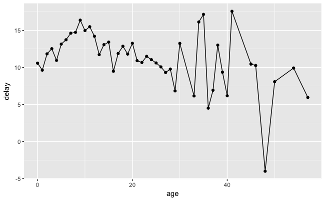

```r
plane_ages <-
  planes %>%
  mutate(age = 2013 - year) %>%
  select(tailnum, age)
flights %>%
  inner_join(plane_ages, by = "tailnum") %>%
  group_by(age) %>%
  filter(!is.na(dep_delay)) %>%
  summarise(delay = mean(dep_delay)) %>%
  ggplot(aes(x = age, y = delay)) +
  geom_point() +
  geom_line()
```

```r
NA
NA
```

4. What weather conditions make it more likely to see a delay?

Almost any amount or precipitation is associated with a delay, though not as strong a trend after 0.02 in as one would expect

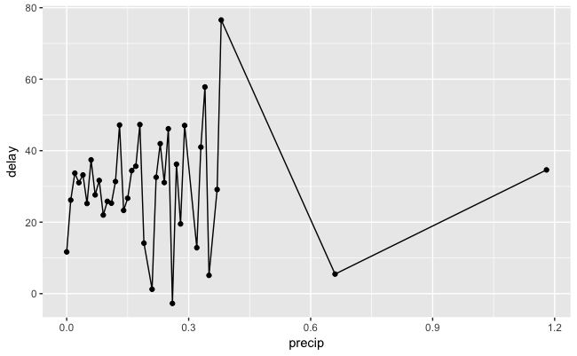

```r
flight_weather <-
  flights %>%
  inner_join(weather, by = c("origin" = "origin",
                            "year" = "year",
                            "month" = "month",
                            "day" = "day",
                            "hour" = "hour"))
flight_weather %>%
  group_by(precip) %>%
  summarise(delay = mean(dep_delay, na.rm = TRUE)) %>%
  ggplot(aes(x = precip, y = delay)) +
    geom_line() + geom_point()
```

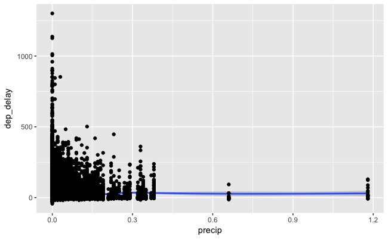

```r
flight_weather %>%
  ggplot(aes(x = precip, y = dep_delay)) +
    geom_smooth() + geom_point()
```

5. What happened on June 13 2013? Display the spatial pattern of delays, and then use Google to cross-reference with the weather.

There was a large series of storms (derechos) in the southeastern US (see June 12-13, 2013 derecho series)

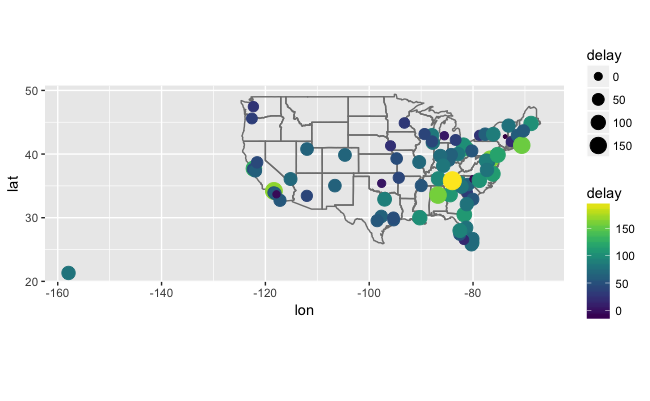

```r
library(viridis)
flights %>%
  filter(year == 2013, month == 6, day == 13) %>%
  group_by(dest) %>%
  summarise(delay = mean(arr_delay, na.rm = TRUE)) %>%
  inner_join(airports, by = c("dest" = "faa")) %>%
  ggplot(aes(y = lat, x = lon, size = delay, colour = delay)) +
  borders("state") +
  geom_point() +
  coord_quickmap() +
  scale_color_viridis()
```

## Filtering Joins

- `semi_join`: keep all obs in `x` with match in `y`
- `anti_join`: drop all obs in `x` with a match in `y`

### Exercises

1. What does it mean for a flight to have a missing `tailnum`? What do the tail numbers that don’t have a matching record in planes have in common? (Hint: one variable explains ~90% of the problems.)

American Airlines (AA) and Envoy Airlines (MQ) don’t report tail numbers.

```r
flights %>%
  anti_join(planes, by = "tailnum") %>%
  count(carrier, sort = TRUE)
```

| carrier | n |
| --- | --- |
| MQ | 25397 |
| AA | 22558 |
| UA | 1693 |
| 9E | 1044 |
| B6 | 830 |
| US | 699 |
| FL | 187 |
| DL | 110 |
| F9 | 50 |
| WN | 38 |

2. Filter flights to only show flights with planes that have flown at least 100 flights.

```r
planes_gt100 <-
  filter(flights) %>%
  group_by(tailnum) %>%
  count() %>%
  filter(n > 100)
glimpse(planes_gt100)
```

```
Observations: 1,201
Variables: 2
$ tailnum <chr> "N0EGMQ", "N10156", "N10575", "N11106", "N11...
$ n       <int> 371, 153, 289, 129, 148, 148, 138, 148, 154,...
```

```r
flights %>%
  semi_join(planes_gt100, by = "tailnum")
```

| year | month | day | dep_time | sched_dep_time | dep_delay | arr_time | sched_arr_time | arr_delay | carrier | flight | tailnum | origin | dest | air_time | distance | hour | minute | time_hour |
| --- | --- | --- | --- | --- | --- | --- | --- | --- | --- | --- | --- | --- | --- | --- | --- | --- | --- | --- |
| 2013 | 1 | 1 | 1604 | 1510 | 54 | 1817 | 1710 | 67 | MQ | 4579 | N0EGMQ | LGA | CLT | 106 | 544 | 15 | 10 | 2013-01-01 15:00:00 |
| 2013 | 1 | 1 | 2100 | 2100 | 0 | 2307 | 2250 | 17 | MQ | 4584 | N0EGMQ | LGA | CLT | 101 | 544 | 21 | 0 | 2013-01-01 21:00:00 |
| 2013 | 1 | 2 | 827 | 835 | -8 | 1059 | 1105 | -6 | MQ | 4610 | N0EGMQ | LGA | ATL | 124 | 762 | 8 | 35 | 2013-01-02 08:00:00 |
| 2013 | 1 | 2 | 2014 | 2020 | -6 | 2256 | 2245 | 11 | MQ | 4662 | N0EGMQ | LGA | ATL | 124 | 762 | 20 | 20 | 2013-01-02 20:00:00 |
| 2013 | 1 | 4 | 1621 | 1625 | -4 | 1853 | 1855 | -2 | MQ | 4661 | N0EGMQ | LGA | ATL | 125 | 762 | 16 | 25 | 2013-01-04 16:00:00 |
| 2013 | 1 | 5 | 834 | 835 | -1 | 1050 | 1105 | -15 | MQ | 4610 | N0EGMQ | LGA | ATL | 119 | 762 | 8 | 35 | 2013-01-05 08:00:00 |
| 2013 | 1 | 6 | 832 | 835 | -3 | 1101 | 1105 | -4 | MQ | 4610 | N0EGMQ | LGA | ATL | 124 | 762 | 8 | 35 | 2013-01-06 08:00:00 |
| 2013 | 1 | 6 | 2051 | 2100 | -9 | 2241 | 2250 | -9 | MQ | 4584 | N0EGMQ | LGA | CLT | 89 | 544 | 21 | 0 | 2013-01-06 21:00:00 |
| 2013 | 1 | 7 | 826 | 835 | -9 | 1057 | 1105 | -8 | MQ | 4610 | N0EGMQ | LGA | ATL | 111 | 762 | 8 | 35 | 2013-01-07 08:00:00 |
| 2013 | 1 | 7 | 1444 | 1445 | -1 | 1659 | 1710 | -11 | MQ | 4669 | N0EGMQ | LGA | ATL | 113 | 762 | 14 | 45 | 2013-01-07 14:00:00 |

[output cut: 990 more lines]

```r
print(nrow(flights))
```

```
[1] 336776
```

3. Combine `fueleconomy::vehicles` and `fueleconomy::common` to find only the records for the most common models.

The table `fueleconomy::common` identifies vehicles by `make` and `model`:

```r
glimpse(fueleconomy::vehicles)
```

```
Observations: 33,442
Variables: 12
$ id    <int> 27550, 28426, 27549, 28425, 1032, 1033, 3347, ...
$ make  <chr> "AM General", "AM General", "AM General", "AM ...
$ model <chr> "DJ Po Vehicle 2WD", "DJ Po Vehicle 2WD", "FJ8...
$ year  <int> 1984, 1984, 1984, 1984, 1985, 1985, 1987, 1997...
$ class <chr> "Special Purpose Vehicle 2WD", "Special Purpos...
$ trans <chr> "Automatic 3-spd", "Automatic 3-spd", "Automat...
$ drive <chr> "2-Wheel Drive", "2-Wheel Drive", "2-Wheel Dri...
$ cyl   <int> 4, 4, 6, 6, 4, 6, 6, 4, 4, 6, 4, 4, 6, 4, 4, 6...
$ displ <dbl> 2.5, 2.5, 4.2, 4.2, 2.5, 4.2, 3.8, 2.2, 2.2, 3...
$ fuel  <chr> "Regular", "Regular", "Regular", "Regular", "R...
$ hwy   <int> 17, 17, 13, 13, 17, 13, 21, 26, 28, 26, 27, 29...
$ cty   <int> 18, 18, 13, 13, 16, 13, 14, 20, 22, 18, 19, 21...
```

```r
glimpse(fueleconomy::common)
```

```
Observations: 347
Variables: 4
$ make  <chr> "Acura", "Acura", "Acura", "Acura", "Acura", "...
$ model <chr> "Integra", "Legend", "MDX 4WD", "NSX", "TSX", ...
$ n     <int> 42, 28, 12, 28, 27, 49, 49, 66, 20, 12, 46, 20...
$ years <int> 16, 10, 12, 14, 11, 19, 15, 19, 19, 12, 20, 15...
```

```r
fueleconomy::vehicles %>%
  semi_join(fueleconomy::common, by = c("make", "model"))
```

| id | make | model | year | class | trans | drive | cyl | displ | fuel | hwy | cty |
| --- | --- | --- | --- | --- | --- | --- | --- | --- | --- | --- | --- |
| 1833 | Acura | Integra | 1986 | Subcompact Cars | Automatic 4-spd | Front-Wheel Drive | 4 | 1.6 | Regular | 28 | 22 |
| 1834 | Acura | Integra | 1986 | Subcompact Cars | Manual 5-spd | Front-Wheel Drive | 4 | 1.6 | Regular | 28 | 23 |
| 3037 | Acura | Integra | 1987 | Subcompact Cars | Automatic 4-spd | Front-Wheel Drive | 4 | 1.6 | Regular | 28 | 22 |
| 3038 | Acura | Integra | 1987 | Subcompact Cars | Manual 5-spd | Front-Wheel Drive | 4 | 1.6 | Regular | 28 | 23 |
| 4183 | Acura | Integra | 1988 | Subcompact Cars | Automatic 4-spd | Front-Wheel Drive | 4 | 1.6 | Regular | 27 | 22 |
| 4184 | Acura | Integra | 1988 | Subcompact Cars | Manual 5-spd | Front-Wheel Drive | 4 | 1.6 | Regular | 28 | 23 |
| 5303 | Acura | Integra | 1989 | Subcompact Cars | Automatic 4-spd | Front-Wheel Drive | 4 | 1.6 | Regular | 27 | 22 |
| 5304 | Acura | Integra | 1989 | Subcompact Cars | Manual 5-spd | Front-Wheel Drive | 4 | 1.6 | Regular | 28 | 23 |
| 6442 | Acura | Integra | 1990 | Subcompact Cars | Automatic 4-spd | Front-Wheel Drive | 4 | 1.8 | Regular | 24 | 20 |
| 6443 | Acura | Integra | 1990 | Subcompact Cars | Manual 5-spd | Front-Wheel Drive | 4 | 1.8 | Regular | 26 | 21 |

[output cut: 990 more lines]

3. Find the 48 hours (over the course of the whole year) that have the worst delays. Cross-reference it with the weather data. Can you see any patterns?
4. What does `anti_join(flights, airports, by = c("dest" = "faa"))` tell you? What does `anti_join(airports, flights, by = c("faa" = "dest"))` tell you?

`anti_join(flights, airports, by = c("dest" = "faa"))` are flights that go to an airport that is not in FAA list of destinations, likely foreign airports.

`anti_join(airports, flights, by = c("faa" = "dest"))` are US airports that don’t have a flight in the data, meaning that there were no flights to that aiport **from** New York in 2013.

5. You might expect that there’s an implicit relationship between plane and airline, because each plane is flown by a single airline. Confirm or reject this hypothesis using the tools you’ve learned above.

```r
flights %>%
  group_by(tailnum, carrier) %>%
  count() %>%
  filter(n() > 1) %>%
  select(tailnum) %>%
  distinct()
```

| tailnum |
| --- |
| N146PQ |
| N153PQ |
| N176PQ |
| N181PQ |
| N197PQ |
| N200PQ |
| N228PQ |
| N232PQ |
| N933AT |
| N935AT |

[output cut: 8 more lines]

```r
NA
```

## Set operations

```r
df1 <- tribble(
  ~x, ~y,
   1,  1,
   2,  1
)
df2 <- tribble(
  ~x, ~y,
   1,  1,
   1,  2
)
```

```r
intersect(df1, df2)
```

| x | y |
| --- | --- |
| 1 | 1 |

```r
union(df1, df2)
```

| x | y |
| --- | --- |
| 1 | 2 |
| 2 | 1 |
| 1 | 1 |

```r
setdiff(df1, df2)
```

| x | y |
| --- | --- |
| 2 | 1 |